# Group-wise imputation of 50K SNP genotypes

Paul Skillin

2026-02-18

# Purpose

This report runs a simple, defensible, group-wise mean imputation for missing genotypes from the 50K array. The goal is to impute within biologically coherent groups (UC, UF, Heirloom, Wild-by-species) so that the imputed values are based on relatives rather than the global mean. This is a pragmatic workflow: given the tiny amount of missing data, group-wise mean imputation is fast and usually sufficient. I save the fully imputed numeric matrix and a small metadata object for provenance.

## Notes on inputs

./Geno Data/FinalGenotypeFile20251104.Rds : genotype matrix (samples x probes). Original coding is -1/0/1 and we convert to 0/1/2.

./Geno Data/DRAFT-10-15-2024-Final_Rosetta_istraw&50K&850K.Rds : UC Rosetta annotation - we will restrict to probes on the 50K array.

./Geno Data/FaFB1_vf_pos.txt : UF/Brilliance probe positions from Mark.

replace_synonyms.R : lab-specific helper for cleaning sample names and extracting Class/Species history.

# Setup and load data

```r
library(dplyr)
library(tibble)
library(ggplot2)

# Load inputs
markerinfo <- readRDS("./Geno Data/FinalGenotypeFile20251104.Rds")
annotUC <- readRDS("./Geno Data/DRAFT-10-15-2024-Final_Rosetta_istraw&50K&850K.Rds")
annotUF <- read.table("./Geno Data/FaFB1_vf_pos.txt", header=TRUE, stringsAsFactors=FALSE)

# Standardize sample names and history fields (lab function)
source("./replace_synonyms.R")
```

# Annotation cleanup

We keep only probes on the 50K array in the UC Rosetta file and rename the UF columns before merging. UC defines the canonical probe list; UF supplies supplementary positions where available.

```r
# Keep only 50K probes from UC Rosetta
annotUC <- annotUC %>% filter(On_50K_Array != "")
annotUC$On_850K_Array <- NULL
annotUC$On_35k_90K_Arrays <- NULL

# Rename UF columns for clarity before joining
annotUF <- annotUF %>%
  rename(
    UF_Chromosome = mappedTo,
    UF_bp = pos,
    UF_note = notes
  )

# Left-join: keep all UC probes, add UF coordinates where present
annot <- annotUC %>%
  left_join(annotUF, by = c("Probe_ID" = "SNP_ID"))

# Quick checks (printed in HTML)
cat("Probes in UC but not found in UF (first 10):\n")
```

```
## Probes in UC but not found in UF (first 10):
```

```r
print(head(setdiff(annotUC$Probe_ID, annotUF$SNP_ID), 10))
```

```
##  [1] "AX-184707485" "AX-184109754" "AX-184454878" "AX-184203629" "AX-184075066"
##  [6] "AX-184156315" "AX-184324091" "AX-184464857" "AX-184368891" "AX-184051310"
```

```r
cat("Count of UC probes not in UF:", length(setdiff(annotUC$Probe_ID, annotUF$SNP_ID)), "\n\n")
```

```
## Count of UC probes not in UF: 3236
```

```r
geno_snps <- colnames(markerinfo)
cat("Probes present in genotype but not in annotation:", length(setdiff(geno_snps, annot$Probe_ID)), "\n")
```

```
## Probes present in genotype but not in annotation: 128
```

```r
cat("Probes present in annotation but not in genotype:", length(setdiff(annot$Probe_ID, geno_snps)), "\n")
```

```
## Probes present in annotation but not in genotype: 0
```

# Genotype prep

Convert -1/0/1 coding to 0/1/2, move sample names into a column, standardize sample IDs, and drop a few problematic samples we do not trust.

```r
# Shift coding -1/0/1 -> 0/1/2
geno <- markerinfo + 1

# Move rownames to Entry column so replace_synonyms can run
geno <- geno %>% as.data.frame() %>% rownames_to_column("Entry")

# Standardize sample names (lab function)
geno <- replace_synonyms(geno, "Entry", type = "entry")
```

```
## Processed 488 total values (488 non-blank candidates).
## Synonyms mode ('entry'): Replaced: 488. Kept (no match): 0. Replaced -> NA: 0.
```

```r
# Drop samples we do not trust
UC_Problems <- c("20B251P105", "20B251P029", "20C420P052", "72C501P002")
geno <- geno %>% filter(!Entry %in% UC_Problems)

# Set rownames for convenience
rownames(geno) <- geno$Entry
```

# Build the grouping table

We will impute within the following groups:

University of California

University of Florida

Heirloom

Wild_Fragaria_chiloensis

Wild_Fragaria_virginiana

If a sample is labeled Wild we subdivide by species. Also force Yasmin into the UF group because of its breeding history.

```r
# Add Class and Species history using the lab helper
geno <- replace_synonyms(geno, "Entry", type = "history", history_col = "Class", collapse_history = NA)
```

```
## Processed 485 total values (485 non-blank candidates).
## History mode: Added using history column 'Class'. Added/populated: 485. Kept (no match): 0. Replaced -> NA: 0.
```

```r
geno <- replace_synonyms(geno, "Entry", type = "history", history_col = "Species", collapse_history = NA)
```

```
## Processed 485 total values (485 non-blank candidates).
## History mode: Added using history column 'Species'. Added/populated: 485. Kept (no match): 0. Replaced -> NA: 0.
```

```r
samples_df <- data.frame(
  sample = geno$Entry,
  group  = ifelse(geno$Class == "Wild", paste(geno$Species), geno$Class),
  stringsAsFactors = FALSE
)

# Force Yasmin into UF
samples_df$group[samples_df$sample == "Yasmin"] <- "University of Florida"

# Show group sizes
print(table(samples_df$group))
```

```
##
##      Fragaria chiloensis      Fragaria virginiana                 Heirloom
##                       14                       13                       58
## University of California    University of Florida
##                      296                      104
```

# Choose probe set and warn about extras

We use annot$Probe_ID as canonical probe list. If the genotype matrix has extra columns not in Rosetta we report them and ignore them for imputation.

```r
snp_cols <- intersect(colnames(geno), annot$Probe_ID)
if(length(snp_cols) == 0) stop("No SNP columns found in geno that match annot$Probe_ID. Check names.")
extra_snps <- setdiff(colnames(geno)[colnames(geno) != "Entry"], snp_cols)
if(length(extra_snps) > 0) message("Warning: ", length(extra_snps), " columns in genotype file not found in Rosetta; they will be ignored here.")
cat("Using", length(snp_cols), "SNPs for imputation.\n")
```

```
## Using 49355 SNPs for imputation.
```

# Group-wise mean imputation

Split the genotype matrix by group, compute means per SNP within each group, fill missing values with the group mean, and if a SNP is entirely missing in a group fall back to the global mean for that SNP.

```r
# Prepare structures
groups <- unique(samples_df$group)
group_indices <- lapply(groups, function(g) which(samples_df$group == g))
names(group_indices) <- groups

geno_mat_all <- data.matrix(geno[, snp_cols, drop = FALSE])  # numeric matrix samples x SNPs
global_means <- colMeans(geno_mat_all, na.rm = TRUE)

imputed_list <- vector("list", length(groups))
names(imputed_list) <- groups

for(g in groups){
  idx <- group_indices[[g]]
  sub_df <- geno[idx, c("Entry", snp_cols), drop = FALSE]
  sub_mat <- data.matrix(sub_df[, snp_cols, drop = FALSE])

  group_means <- colMeans(sub_mat, na.rm = TRUE)
  nan_cols <- which(is.nan(group_means) | is.na(group_means))

  nas_loc <- which(is.na(sub_mat), arr.ind = TRUE)
  if(nrow(nas_loc) > 0){
    for(k in seq_len(nrow(nas_loc))){
      r <- nas_loc[k,1]; c <- nas_loc[k,2]
      if(!(c %in% nan_cols)){
        sub_mat[r, c] <- group_means[c]
      } else {
        sub_mat[r, c] <- global_means[c]
      }
    }
  }

  # Keep original probe names; set names explicitly to avoid R's syntactic conversion
  imputed_list[[g]] <- data.frame(Entry = sub_df$Entry,
                                  as.data.frame(sub_mat, stringsAsFactors = FALSE),
                                  check.names = FALSE, stringsAsFactors = FALSE)
  colnames(imputed_list[[g]]) <- c("Entry", snp_cols)
}
```

# Reassemble and check

```r
imputed_combined <- do.call(rbind, imputed_list)
imputed_combined <- imputed_combined[match(geno$Entry, imputed_combined$Entry), ]
stopifnot(all(imputed_combined$Entry == geno$Entry))

imputed_matrix <- data.matrix(imputed_combined[, snp_cols, drop = FALSE])
rownames(imputed_matrix) <- imputed_combined$Entry

total_NA_before <- sum(is.na(geno_mat_all))
total_NA_after  <- sum(is.na(imputed_matrix))
message("Total NA before imputation: ", total_NA_before)
message("Total NA after group-wise imputation: ", total_NA_after)
if(total_NA_after > 0){
  message("Top 10 SNPs by remaining NA count:")
  print(head(sort(colSums(is.na(imputed_matrix)), decreasing = TRUE), 10))
}
```

# Save outputs

Save the numeric imputed matrix and a small metadata object for provenance. Compression is used to keep files small.

```r
# Save the numeric imputed matrix for downstream use
saveRDS(imputed_matrix,
        "./Geno Data/FullyImputedGenotypes20260218_012encoding.Rds",
        compress = "xz")

# Save samples and annotation for provenance
saveRDS(list(samples = samples_df, annotation = annot),
        "./Geno Data/Imputation_metadata_20260218.Rds",
        compress = "xz")

# Make the variable that later code expects
geno_imp <- imputed_matrix
```

# Remove monomorphic SNPs and run a diagnostic PCA

PCA cannot scale constant columns, so remove SNPs with zero or near-zero variance. This PCA is only a quick sanity check, not required for downstream imputation work.

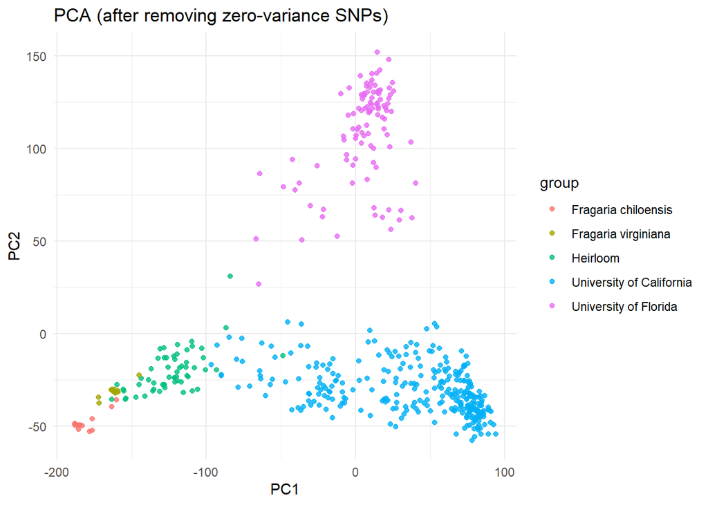

```r
snp_var <- apply(geno_imp, 2, var, na.rm = TRUE)
eps <- 1e-12
zero_var_idx <- which(is.na(snp_var) | snp_var <= eps)
length_zero <- length(zero_var_idx)
total_snps <- ncol(geno_imp)
message("Found ", length_zero, " / ", total_snps, " SNPs with zero (or near-zero) variance.")

if(length_zero > 0){
  removed_snps <- colnames(geno_imp)[zero_var_idx]
  write.table(data.frame(Probe_ID = removed_snps),
              file = "./Geno Data/removed_zero_variance_snps.tsv",
              sep = "\t", row.names = FALSE, quote = FALSE)
  message("Wrote ./Geno Data/removed_zero_variance_snps.tsv")
}

if(length_zero == 0){
  geno_imp_filt <- geno_imp
} else {
  keep_idx <- setdiff(seq_len(ncol(geno_imp)), zero_var_idx)
  geno_imp_filt <- geno_imp[, keep_idx, drop = FALSE]
  message("Keeping ", ncol(geno_imp_filt), " SNPs for PCA.")
}

# PCA (diagnostic)
pca <- prcomp(scale(geno_imp_filt), center = TRUE, retx = TRUE)

pc_df <- data.frame(sample = rownames(geno_imp_filt),
                    PC1 = pca$x[,1],
                    PC2 = pca$x[,2],
                    group = samples_df$group,
                    stringsAsFactors = FALSE)

ggplot(pc_df, aes(PC1, PC2, color = group)) +
  geom_point(alpha = 0.8) + theme_minimal() + labs(title = "PCA (after removing zero-variance SNPs)")
```